# 重賞レース予測レポート【毎時自動更新中】

作成日時: 2026/03/01 15:07:31

☞ [マニュアル(pdf)](https://ryutoro-galois.github.io/keiba-predictor/manual/manual.pdf)

☞ 過去6年の同一レース結果: [2025年](https://ryutoro-galois.github.io/keiba-predictor/report/PredResult_2025y_raceDate_20250301_20250302.html), [2024年](https://ryutoro-galois.github.io/keiba-predictor/report/PredResult_2024y_raceDate_20240225_20240225.html), [2023年](https://ryutoro-galois.github.io/keiba-predictor/report/PredResult_2023y_raceDate_20230226_20230226.html), [2022年](https://ryutoro-galois.github.io/keiba-predictor/report/PredResult_2022y_raceDate_20220227_20220227.html), [2021年](https://ryutoro-galois.github.io/keiba-predictor/report/PredResult_2021y_raceDate_20210228_20210228.html), [2020年](https://ryutoro-galois.github.io/keiba-predictor/report/PredResult_2020y_raceDate_20200301_20200301.html)

☞ 過去4週間の別レース結果: [1週前(2/21-22)](https://ryutoro-galois.github.io/keiba-predictor/report/PredResult_2026y_raceDate_20260221_20260222.html), [2週前(2/14-15)](https://ryutoro-galois.github.io/keiba-predictor/report/PredResult_2026y_raceDate_20260214_20260215.html), [3週前(2/8)](https://ryutoro-galois.github.io/keiba-predictor/report/PredResult_2026y_raceDate_20260208_20260208.html), [4週前(2/1)](https://ryutoro-galois.github.io/keiba-predictor/report/PredResult_2026y_raceDate_20260201_20260201.html)

## 0. 推し馬予測 (AI予測)

### 【オーシャンステークス(GⅢ) 2026/02/28(土)】

- 本命(◎): 1-3着内確率(勝負強さ)が1位の馬
- 対抗(◯): 1-3着内確率が2-N位(20%程度以上)の中で予測タイムが最も速い馬
- 3番手(▲): 1-3着内確率が2-N位(20%程度以上)のでダークホース確率が最も高い馬
- 穴: ダークホース確率が上位1-M位(40%程度以上)の中で1-3着内確率が最も高い馬

| 推し馬 | 枠番 | 馬番 | 人気 | オッズ | 馬名 | 騎手 | 調教師 | 予測タイム(sec) | 1_順位 | 1-3着内確率(%) | 2_順位 | ﾀﾞｰｸﾎｰｽ確率(%) | 3_順位 |
| --- | --- | --- | --- | --- | --- | --- | --- | --- | --- | --- | --- | --- | --- |
| 本命(◎) | 1 | 1 | 2 | 3.9 | ファンダム | Ｃ．ルメール | 辻哲英 | 68.6 | 7 | 55.5 | 1 | 0.4 | 13 |
| 対抗(◯) | 5 | 9 | 6 | 14.6 | インビンシブルパパ | 佐々木大輔 | 伊藤大士 | 67.8 | 4 | 22.6 | 6 | 1.0 | 10 |
| 3番手(▲) | 2 | 3 | 7 | 16.7 | ペアポルックス | 岩田康誠 | 梅田智之 | 70.8 | 8 | 24.6 | 5 | 0.9 | 11 |
| 穴 | 2 | 4 | 10 | 37.5 | ウイングレイテスト | 松岡正海 | 畠山吉宏 | 79.2 | 16 | 18.2 | 8 | 17.9 | 5 |

### 【中山記念(GⅡ) 2026/03/01(日)】

- 本命(◎): 1-3着内確率(勝負強さ)が1位の馬
- 対抗(◯): 1-3着内確率が2-N位(20%程度以上)の中で予測タイムが最も速い馬
- 3番手(▲): 1-3着内確率が2-N位(20%程度以上)のでダークホース確率が最も高い馬
- 穴: ダークホース確率が上位1-M位(40%程度以上)の中で1-3着内確率が最も高い馬

| 推し馬 | 枠番 | 馬番 | 人気 | オッズ | 馬名 | 騎手 | 調教師 | 予測タイム(sec) | 1_順位 | 1-3着内確率(%) | 2_順位 | ﾀﾞｰｸﾎｰｽ確率(%) | 3_順位 |
| --- | --- | --- | --- | --- | --- | --- | --- | --- | --- | --- | --- | --- | --- |
| 本命(◎) | 4 | 5 | 3 | 4.5 | レーベンスティール | 戸崎圭太 | 田中博康 | 116.2 | 9 | 45.6 | 1 | 0.6 | 12 |
| 対抗(◯) | 6 | 9 | 5 | 6.6 | カラマティアノス | 津村明秀 | 奥村武 | 107.4 | 4 | 28.3 | 3 | 0.5 | 14 |
| 3番手(▲) | 8 | 14 | 7 | 17.4 | シャンパンカラー | 岩田康誠 | 田中剛 | 120.3 | 14 | 20.6 | 5 | 1.1 | 9 |
| 穴 | 3 | 4 | 14 | 160.1 | スパークリシャール | 柴田善臣 | 小島茂之 | 111.5 | 6 | 4.4 | 11 | 51.3 | 1 |

### 【チューリップ賞(GⅡ) 2026/03/01(日)】

- 本命(◎): 1-3着内確率(勝負強さ)が1位の馬
- 対抗(◯): 1-3着内確率が2-N位(20%程度以上)の中で予測タイムが最も速い馬
- 3番手(▲): 1-3着内確率が2-N位(20%程度以上)のでダークホース確率が最も高い馬
- 穴: ダークホース確率が上位1-M位(40%程度以上)の中で1-3着内確率が最も高い馬

| 推し馬 | 枠番 | 馬番 | 人気 | オッズ | 馬名 | 騎手 | 調教師 | 予測タイム(sec) | 1_順位 | 1-3着内確率(%) | 2_順位 | ﾀﾞｰｸﾎｰｽ確率(%) | 3_順位 |
| --- | --- | --- | --- | --- | --- | --- | --- | --- | --- | --- | --- | --- | --- |
| 本命(◎) | 7 | 13 | 2 | 4.8 | タイセイボーグ | 西村淳也 | 松下武士 | 93.4 | 3 | 33.0 | 1 | 0.5 | 14.5 |
| 対抗(◯) | 3 | 4 | 5 | 13.4 | スマートプリエール | 吉村誠之助 | 大久保龍志 | 93.4 | 3 | 23.2 | 3 | 1.2 | 9.0 |
| 3番手(▲) | 3 | 5 | 4 | 7.6 | ソルパッサーレ | 浜中俊 | 四位洋文 | 102.4 | 11 | 29.2 | 2 | 0.9 | 12.0 |
| 穴 | 4 | 7 | 11 | 35.4 | サキドリトッケン | 飛田愛斗 | 真島元徳 | 95.1 | 6 | 10.8 | 8 | 40.0 | 1.0 |

## 1. 予測チャート (タイム/勝負強さ)

### 【オーシャンステークス(GⅢ)】

2026/02/28(土), 06_中山, 芝右外1200m

[interactive chart not shown]

### 【中山記念(GⅡ)】

2026/03/01(日), 06_中山, 芝右1800m

[interactive chart not shown]

### 【チューリップ賞(GⅡ)】

2026/03/01(日), 09_阪神, 芝右外1600m

[interactive chart not shown]

## 2. オッズモニタリング (毎時)

### 【オーシャンステークス】

[interactive chart not shown]

### 【中山記念】

[interactive chart not shown]

### 【チューリップ賞】

[interactive chart not shown]

## 3. 出馬表

### 【オーシャンステークス 2026/02/28(土) 】

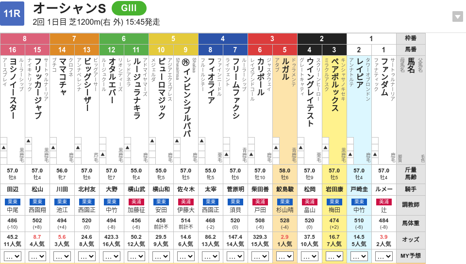

### 【中山記念 2026/03/01(日) 】

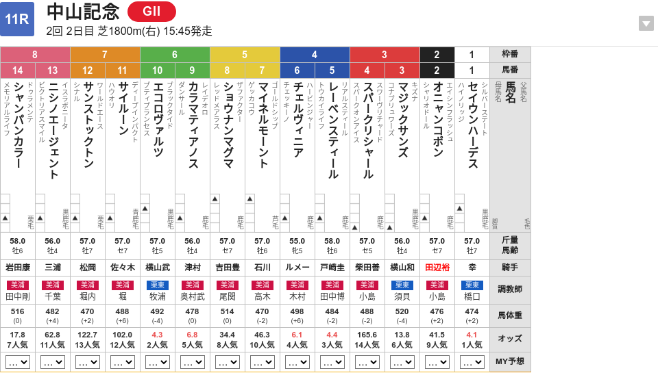

### 【チューリップ賞 2026/03/01(日) 】

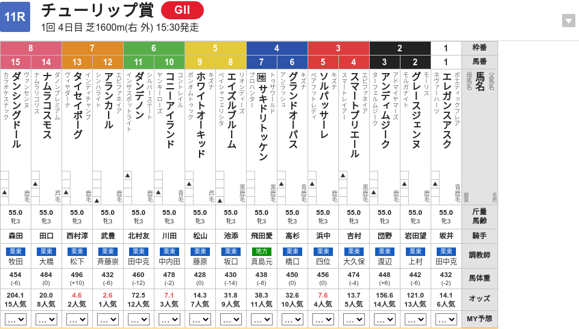

## 4. 単勝予測結果

### 【オーシャンステークス(GⅢ) 2026/02/28(土)】

| 枠番 | 馬番 | 人気 | オッズ | 馬名 | 騎手 | 調教師 | 予測タイム(sec) | 1_順位 | 1-3着内確率(%) | 2_順位 | ﾀﾞｰｸﾎｰｽ確率(%) | 3_順位 |
| --- | --- | --- | --- | --- | --- | --- | --- | --- | --- | --- | --- | --- |
| 1 | 1 | 2 | 3.9 | ファンダム | Ｃ．ルメール | 辻哲英 | 68.6 | 7.0 | 55.5 | 1 | 0.4 | 13 |
| 1 | 2 | 5 | 14.5 | レイピア | 戸崎圭太 | 中竹和也 | 67.9 | 5.0 | 26.1 | 4 | 0.8 | 12 |
| 2 | 3 | 7 | 16.7 | ペアポルックス | 岩田康誠 | 梅田智之 | 70.8 | 8.0 | 24.6 | 5 | 0.9 | 11 |
| 2 | 4 | 10 | 37.5 | ウイングレイテスト | 松岡正海 | 畠山吉宏 | 79.2 | 16.0 | 18.2 | 8 | 17.9 | 5 |
| 3 | 5 | 1 | 2.9 | ルガル | 鮫島克駿 | 杉山晴紀 | 67.1 | 1.5 | 9.8 | 11 | 0.4 | 15 |
| 3 | 6 | 15 | 329.3 | カリボール | 柴田善臣 | 戸田博文 | 77.0 | 14.0 | 7.2 | 12 | 12.2 | 7 |
| 4 | 7 | 14 | 147.4 | フリームファクシ | 菅原明良 | 須貝尚介 | 76.4 | 12.0 | 3.4 | 15 | 34.5 | 3 |
| 4 | 8 | 13 | 86.2 | フィオライア | 太宰啓介 | 西園正都 | 67.1 | 1.5 | 11.2 | 10 | 39.0 | 1 |
| 5 | 9 | 6 | 14.6 | インビンシブルパパ | 佐々木大輔 | 伊藤大士 | 67.8 | 4.0 | 22.6 | 6 | 1.0 | 10 |
| 5 | 10 | 9 | 29.5 | ピューロマジック | 横山和生 | 安田翔伍 | 75.8 | 10.0 | 5.4 | 13 | 8.3 | 8 |

[output cut: 6 more lines]

### 【中山記念(GⅡ) 2026/03/01(日)】

| 枠番 | 馬番 | 人気 | オッズ | 馬名 | 騎手 | 調教師 | 予測タイム(sec) | 1_順位 | 1-3着内確率(%) | 2_順位 | ﾀﾞｰｸﾎｰｽ確率(%) | 3_順位 |
| --- | --- | --- | --- | --- | --- | --- | --- | --- | --- | --- | --- | --- |
| 1 | 1 | 1 | 4.0 | セイウンハーデス | 幸英明 | 橋口慎介 | 105.5 | 1 | 7.8 | 7 | 0.6 | 10 |
| 2 | 2 | 9 | 41.1 | オニャンコポン | 田辺裕信 | 小島茂之 | 117.1 | 11 | 5.4 | 9 | 16.1 | 6 |
| 3 | 3 | 6 | 13.7 | マジックサンズ | 横山和生 | 須貝尚介 | 105.7 | 2 | 17.2 | 6 | 1.2 | 8 |
| 3 | 4 | 14 | 160.1 | スパークリシャール | 柴田善臣 | 小島茂之 | 111.5 | 6 | 4.4 | 11 | 51.3 | 1 |
| 4 | 5 | 3 | 4.5 | レーベンスティール | 戸崎圭太 | 田中博康 | 116.2 | 9 | 45.6 | 1 | 0.6 | 12 |
| 4 | 6 | 4 | 6.2 | チェルヴィニア | Ｃ．ルメール | 木村哲也 | 111.1 | 5 | 28.1 | 4 | 0.6 | 11 |
| 5 | 7 | 10 | 49.6 | マイネルモーント | 石川裕紀人 | 高木登 | 112.0 | 7 | 6.6 | 8 | 34.5 | 3 |
| 5 | 8 | 8 | 33.0 | ショウナンマグマ | 吉田豊 | 尾関知人 | 117.0 | 10 | 2.1 | 14 | 9.3 | 7 |
| 6 | 9 | 5 | 6.6 | カラマティアノス | 津村明秀 | 奥村武 | 107.4 | 4 | 28.3 | 3 | 0.5 | 14 |
| 6 | 10 | 2 | 4.4 | エコロヴァルツ | 横山武史 | 牧浦充徳 | 113.5 | 8 | 40.7 | 2 | 0.6 | 13 |

[output cut: 4 more lines]

### 【チューリップ賞(GⅡ) 2026/03/01(日)】

| 枠番 | 馬番 | 人気 | オッズ | 馬名 | 騎手 | 調教師 | 予測タイム(sec) | 1_順位 | 1-3着内確率(%) | 2_順位 | ﾀﾞｰｸﾎｰｽ確率(%) | 3_順位 |
| --- | --- | --- | --- | --- | --- | --- | --- | --- | --- | --- | --- | --- |
| 1 | 1 | 6 | 13.8 | エレガンスアスク | 坂井瑠星 | 田中克典 | 93.4 | 3 | 18.6 | 4 | 1.1 | 10.0 |
| 2 | 2 | 13 | 114.6 | グレースジェンヌ | 岩田望来 | 上村洋行 | 101.7 | 8 | 2.8 | 12 | 13.7 | 5.0 |
| 2 | 3 | 14 | 143.9 | アンディムジーク | 団野大成 | 渡辺薫彦 | 101.9 | 9 | 2.6 | 13 | 13.0 | 6.0 |
| 3 | 4 | 5 | 13.4 | スマートプリエール | 吉村誠之助 | 大久保龍志 | 93.4 | 3 | 23.2 | 3 | 1.2 | 9.0 |
| 3 | 5 | 4 | 7.6 | ソルパッサーレ | 浜中俊 | 四位洋文 | 102.4 | 11 | 29.2 | 2 | 0.9 | 12.0 |
| 4 | 6 | 10 | 32.6 | グランドオーパス | 高杉吏麒 | 橋口慎介 | 103.0 | 13 | 3.4 | 11 | 23.7 | 3.0 |
| 4 | 7 | 11 | 35.4 | サキドリトッケン | 飛田愛斗 | 真島元徳 | 95.1 | 6 | 10.8 | 8 | 40.0 | 1.0 |
| 5 | 8 | 9 | 29.5 | エイズルブルーム | 池添謙一 | 坂口智康 | 103.0 | 14 | 3.4 | 10 | 27.5 | 2.0 |
| 5 | 9 | 7 | 14.5 | ホワイトオーキッド | 松山弘平 | 藤原英昭 | 93.4 | 3 | 13.5 | 6 | 1.1 | 11.0 |
| 6 | 10 | 3 | 7.0 | コニーアイランド | 川田将雅 | 中内田充正 | 103.3 | 15 | 12.1 | 7 | 0.9 | 13.0 |

[output cut: 5 more lines]

## 5. 人気と着順の乖離率推移

### 【オーシャンステークス_2006y_2019y】

[interactive chart not shown]

### 【中山記念_1990y_2019y】

[interactive chart not shown]

### 【チューリップ賞_1994y_2019y】

[interactive chart not shown]

### 【オーシャンステークス_2006y_2019y】

| No | 開催年 | 不整合率(%) | 頭数 | 人気別着順(1-3位) | 人気別着順(全体) |
| --- | --- | --- | --- | --- | --- |
| 14 | 2019 | 21.2 | 16頭 | 1-2-7 | 1\|2\|7\|6\|13\|8\|9\|10\|12\|3\|5\|11\|15\|16\|14\|4 |
| 13 | 2018 | 31.4 | 16頭 | 10-2-1 | 10\|2\|1\|6\|4\|3\|11\|9\|13\|7\|8\|12\|15\|16\|14\|5 |
| 12 | 2017 | 22.3 | 16頭 | 1-3-4 | 1\|3\|4\|2\|5\|10\|9\|6\|13\|12\|11\|8\|14\|7\|15\|16 |
| 11 | 2016 | 50.5 | 16頭 | 5-4-8 | 5\|4\|8\|2\|1\|7\|13\|10\|15\|11\|14\|12\|6\|3\|16\|9 |
| 10 | 2015 | 28.2 | 16頭 | 7-1-4 | 7\|1\|4\|13\|9\|2\|5\|10\|12\|3\|11\|8\|6\|15\|16\|14 |
| 9 | 2014 | 67.6 | 16頭 | 3-11-9 | 3\|11\|9\|10\|6\|7\|13\|2\|12\|5\|15\|4\|1\|8\|16\|14 |
| 8 | 2013 | 25.2 | 16頭 | 2-1-7 | 2\|1\|7\|15\|13\|12\|16\|8\|3\|10\|4\|5\|6\|11\|9\|14 |
| 7 | 2012 | 38.2 | 16頭 | 9-5-14 | 9\|5\|14\|1\|3\|6\|4\|15\|2\|7\|10\|13\|8\|11\|16\|12 |
| 6 | 2011 | 42.2 | 16頭 | 3-2-1 | 3\|2\|1\|4\|8\|7\|12\|13\|10\|5\|14\|9\|11\|6\|15\|16 |
| 5 | 2010 | 55.6 | 16頭 | 2-7-8 | 2\|7\|8\|5\|16\|11\|10\|14\|13\|3\|15\|4\|12\|9\|6\|1 |

[output cut: 4 more lines]

### 【中山記念_1990y_2019y】

| No | 開催年 | 不整合率(%) | 頭数 | 人気別着順(1-3位) | 人気別着順(全体) |
| --- | --- | --- | --- | --- | --- |
| 30 | 2019 | 59.3 | 11頭 | 5-6-2 | 5\|6\|2\|4\|3\|1\|7\|8\|9\|10\|11 |
| 29 | 2018 | 44.6 | 10頭 | 2-5-6 | 2\|5\|6\|4\|1\|8\|9\|3\|10\|7 |
| 28 | 2017 | 48.4 | 11頭 | 3-8-7 | 3\|8\|7\|1\|4\|5\|6\|2\|9\|11\|10 |
| 27 | 2016 | 24.2 | 11頭 | 1-4-2 | 1\|4\|2\|6\|8\|7\|5\|10\|3\|9\|11 |
| 26 | 2015 | 49.8 | 11頭 | 3-2-4 | 3\|2\|4\|5\|1\|6\|11\|7\|8\|10\|9 |
| 25 | 2014 | 46.1 | 15頭 | 2-4-3 | 2\|4\|3\|11\|7\|1\|15\|9\|14\|8\|12\|10\|6\|5\|13 |
| 24 | 2013 | 33.3 | 15頭 | 2-3-8 | 2\|3\|8\|1\|5\|4\|9\|7\|12\|11\|6\|10\|13\|14\|15 |
| 23 | 2012 | 61.1 | 11頭 | 3-7-4 | 3\|7\|4\|9\|11\|5\|10\|8\|6\|1\|2 |
| 22 | 2011 | 32.2 | 12頭 | 1-4-3 | 1\|4\|3\|6\|5\|2\|11\|7\|8\|10\|9\|12 |
| 21 | 2010 | 42.9 | 16頭 | 13-12-5 | 13\|12\|5\|8\|6\|2\|1\|9\|11\|3\|16\|10\|4\|14\|7\|15 |

[output cut: 20 more lines]

### 【チューリップ賞_1994y_2019y】

| No | 開催年 | 不整合率(%) | 頭数 | 人気別着順(1-3位) | 人気別着順(全体) |
| --- | --- | --- | --- | --- | --- |
| 26 | 2019 | 27.0 | 13頭 | 1-4-7 | 1\|4\|7\|6\|2\|5\|9\|8\|3\|13\|12\|10\|11 |
| 25 | 2018 | 16.6 | 10頭 | 1-3-2 | 1\|3\|2\|4\|8\|5\|6\|9\|10\|7 |
| 24 | 2017 | 9.3 | 12頭 | 1-7-2 | 1\|7\|2\|3\|8\|4\|5\|10\|12\|6\|9\|11 |
| 23 | 2016 | 27.4 | 16頭 | 2-1-10 | 2\|1\|10\|12\|6\|9\|14\|3\|16\|4\|7\|8\|13\|5\|15\|11 |
| 22 | 2015 | 50.3 | 17頭 | 5-7-2 | 5\|7\|2\|3\|12\|4\|16\|9\|8\|13\|1\|17\|11\|6\|10\|14\|15 |
| 21 | 2014 | 31.0 | 13頭 | 1-4-6 | 1\|4\|6\|7\|11\|5\|10\|8\|2\|3\|9\|12\|13 |
| 20 | 2013 | 54.4 | 15頭 | 3-7-5 | 3\|7\|5\|4\|6\|9\|1\|8\|2\|10\|12\|11\|15\|14\|13 |
| 19 | 2012 | 44.1 | 14頭 | 4-3-1 | 4\|3\|1\|2\|7\|9\|5\|6\|8\|13\|14\|10\|11\|12 |
| 18 | 2011 | 14.3 | 12頭 | 1-2-6 | 1\|2\|6\|4\|8\|3\|5\|7\|10\|12\|9\|11 |
| 17 | 2010 | 17.9 | 16頭 | 9-1-8 | 9\|1\|8\|2\|6\|12\|3\|16\|4\|5\|11\|10\|15\|7\|13\|14 |

[output cut: 16 more lines]

## 6. 1-3番人気馬の着順分類予測

### 【オーシャンステークス】

| 分類 | 凡例 | 発生確率(%) | 当該レース | 当該レースランク | 直近1年間 |
| --- | --- | --- | --- | --- | --- |
| 4: 1,2番人気のみ (4_pop12) | 1 \| 2 \| * | 19.8 | 0.44 | 0.51 | 0.59 |
| 1: 1番人気のみ (1_pop1) | 1 \| * \| * | 16.4 | 1.09 | 1.21 | 0.49 |
| 8: 1,2,3番人気すべて着外 (8_darkhorse) | * \| * \| * | 15.3 | 0.76 | 1.34 | 0.00 |
| 5: 1,3番人気のみ (5_pop13) | 1 \| 3 \| * | 12.9 | 2.58 | 1.90 | 0.00 |
| 3: 3番人気のみ (3_pop3) | 3 \| * \| * | 10.4 | 1.04 | 1.14 | 0.00 |
| 6: 2,3番人気のみ (6_pop23) | 2 \| 3 \| * | 9.3 | 0.00 | 4.04 | 0.00 |
| 2: 2番人気のみ (2_pop2) | 2 \| * \| * | 8.9 | 0.00 | 0.98 | 0.27 |
| 7: 1,2,3番人気すべて着内 (7_pop123) | 1 \| 2 \| 3 | 7.2 | 1.44 | 0.79 | 0.00 |

### 【中山記念】

| 分類 | 凡例 | 発生確率(%) | 当該レース | 当該レースランク | 直近1年間 |
| --- | --- | --- | --- | --- | --- |
| 4: 1,2番人気のみ (4_pop12) | 1 \| 2 \| * | 19.8 | 1.42 | 1.74 | 0.00 |
| 1: 1番人気のみ (1_pop1) | 1 \| * \| * | 16.4 | 1.48 | 0.66 | 0.33 |
| 8: 1,2,3番人気すべて着外 (8_darkhorse) | * \| * \| * | 15.3 | 1.10 | 1.34 | 0.00 |
| 5: 1,3番人気のみ (5_pop13) | 1 \| 3 \| * | 12.9 | 1.16 | 1.42 | 0.00 |
| 3: 3番人気のみ (3_pop3) | 3 \| * \| * | 10.4 | 1.86 | 2.31 | 0.00 |
| 6: 2,3番人気のみ (6_pop23) | 2 \| 3 \| * | 9.3 | 0.67 | 0.82 | 0.00 |
| 2: 2番人気のみ (2_pop2) | 2 \| * \| * | 8.9 | 0.36 | 0.43 | 0.18 |
| 7: 1,2,3番人気すべて着内 (7_pop123) | 1 \| 2 \| 3 | 7.2 | 1.29 | 1.06 | 0.00 |

### 【チューリップ賞】

| 分類 | 凡例 | 発生確率(%) | 当該レース | 当該レースランク | 直近1年間 |
| --- | --- | --- | --- | --- | --- |
| 2: 2番人気のみ (2_pop2) | 2 \| * \| * | 16.5 | 1.32 | 0.80 | 0.33 |
| 1: 1番人気のみ (1_pop1) | 1 \| * \| * | 15.9 | 0.51 | 0.64 | 0.32 |
| 4: 1,2番人気のみ (4_pop12) | 1 \| 2 \| * | 14.9 | 0.60 | 1.31 | 0.00 |
| 8: 1,2,3番人気すべて着外 (8_darkhorse) | * \| * \| * | 14.3 | 4.61 | 1.25 | 0.00 |
| 5: 1,3番人気のみ (5_pop13) | 1 \| 3 \| * | 12.9 | 2.08 | 1.42 | 0.00 |
| 3: 3番人気のみ (3_pop3) | 3 \| * \| * | 10.2 | 1.65 | 2.27 | 0.00 |
| 6: 2,3番人気のみ (6_pop23) | 2 \| 3 \| * | 8.2 | 2.65 | 0.72 | 0.00 |
| 7: 1,2,3番人気すべて着内 (7_pop123) | 1 \| 2 \| 3 | 7.0 | 0.56 | 1.03 | 0.00 |

## 7. 3連複予測結果

### 【オーシャンステークス(GⅢ) 2026/02/28(土)】

| 分類 | 馬番 | 枠番 | 人気 | 平均予測タイム(sec) | 1-3着内確率(%) | ﾀﾞｰｸﾎｰｽ確率(%) | 馬名 | 騎手 | 調教師 |
| --- | --- | --- | --- | --- | --- | --- | --- | --- | --- |
| 6: 2,3番人気のみ (6_pop23) | 1-14-15 | 1-7-8 | 2-3-4 | 74.47 | 5.70 | 0.00 | ファンダム \| ママコチャ \| フリッカージャブ | Ｃ．ルメール \| 川田将雅 \| 松山弘平 | 辻哲英 \| 池江泰寿 \| 西園翔太 |
| 6: 2,3番人気のみ (6_pop23) | 1-14-2 | 1-7-1 | 2-3-5 | 71.53 | 5.53 | 0.00 | ファンダム \| ママコチャ \| レイピア | Ｃ．ルメール \| 川田将雅 \| 戸崎圭太 | 辻哲英 \| 池江泰寿 \| 中竹和也 |
| 6: 2,3番人気のみ (6_pop23) | 1-14-3 | 1-7-2 | 2-3-7 | 72.50 | 5.20 | 0.00 | ファンダム \| ママコチャ \| ペアポルックス | Ｃ．ルメール \| 川田将雅 \| 岩田康誠 | 辻哲英 \| 池江泰寿 \| 梅田智之 |
| 6: 2,3番人気のみ (6_pop23) | 1-14-9 | 1-7-5 | 2-3-6 | 71.50 | 4.78 | 0.00 | ファンダム \| ママコチャ \| インビンシブルパパ | Ｃ．ルメール \| 川田将雅 \| 佐々木大輔 | 辻哲英 \| 池江泰寿 \| 伊藤大士 |
| 2: 2番人気のみ (2_pop2) | 1-15-2 | 1-8-1 | 2-4-5 | 71.07 | 3.91 | 0.00 | ファンダム \| フリッカージャブ \| レイピア | Ｃ．ルメール \| 松山弘平 \| 戸崎圭太 | 辻哲英 \| 西園翔太 \| 中竹和也 |
| 6: 2,3番人気のみ (6_pop23) | 1-14-13 | 1-7-7 | 2-3-8 | 71.50 | 3.87 | 0.00 | ファンダム \| ママコチャ \| ビッグシーザー | Ｃ．ルメール \| 川田将雅 \| 北村友一 | 辻哲英 \| 池江泰寿 \| 西園正都 |
| 6: 2,3番人気のみ (6_pop23) | 1-14-4 | 1-7-2 | 2-3-10 | 75.30 | 3.85 | 0.00 | ファンダム \| ママコチャ \| ウイングレイテスト | Ｃ．ルメール \| 川田将雅 \| 松岡正海 | 辻哲英 \| 池江泰寿 \| 畠山吉宏 |
| 2: 2番人気のみ (2_pop2) | 1-15-3 | 1-8-2 | 2-4-7 | 72.03 | 3.68 | 0.00 | ファンダム \| フリッカージャブ \| ペアポルックス | Ｃ．ルメール \| 松山弘平 \| 岩田康誠 | 辻哲英 \| 西園翔太 \| 梅田智之 |
| 2: 2番人気のみ (2_pop2) | 1-2-3 | 1-1-2 | 2-5-7 | 69.10 | 3.56 | 0.00 | ファンダム \| レイピア \| ペアポルックス | Ｃ．ルメール \| 戸崎圭太 \| 岩田康誠 | 辻哲英 \| 中竹和也 \| 梅田智之 |
| 2: 2番人気のみ (2_pop2) | 1-15-9 | 1-8-5 | 2-4-6 | 71.03 | 3.38 | 0.00 | ファンダム \| フリッカージャブ \| インビンシブルパパ | Ｃ．ルメール \| 松山弘平 \| 佐々木大輔 | 辻哲英 \| 西園翔太 \| 伊藤大士 |

[output cut: 550 more lines]

### 【中山記念(GⅡ) 2026/03/01(日)】

| 分類 | 馬番 | 枠番 | 人気 | 平均予測タイム(sec) | 1-3着内確率(%) | ﾀﾞｰｸﾎｰｽ確率(%) | 馬名 | 騎手 | 調教師 |
| --- | --- | --- | --- | --- | --- | --- | --- | --- | --- |
| 6: 2,3番人気のみ (6_pop23) | 10-5-9 | 6-4-6 | 2-3-5 | 112.37 | 5.26 | 0.00 | エコロヴァルツ \| レーベンスティール \| カラマティアノス | 横山武史 \| 戸崎圭太 \| 津村明秀 | 牧浦充徳 \| 田中博康 \| 奥村武 |
| 6: 2,3番人気のみ (6_pop23) | 10-5-6 | 6-4-4 | 2-3-4 | 113.60 | 5.22 | 0.00 | エコロヴァルツ \| レーベンスティール \| チェルヴィニア | 横山武史 \| 戸崎圭太 \| Ｃ．ルメール | 牧浦充徳 \| 田中博康 \| 木村哲也 |
| 6: 2,3番人気のみ (6_pop23) | 10-5-14 | 6-4-8 | 2-3-7 | 116.67 | 3.82 | 0.00 | エコロヴァルツ \| レーベンスティール \| シャンパンカラー | 横山武史 \| 戸崎圭太 \| 岩田康誠 | 牧浦充徳 \| 田中博康 \| 田中剛 |
| 3: 3番人気のみ (3_pop3) | 5-6-9 | 4-4-6 | 3-4-5 | 111.57 | 3.63 | 0.00 | レーベンスティール \| チェルヴィニア \| カラマティアノス | 戸崎圭太 \| Ｃ．ルメール \| 津村明秀 | 田中博康 \| 木村哲也 \| 奥村武 |
| 2: 2番人気のみ (2_pop2) | 10-6-9 | 6-4-6 | 2-4-5 | 110.67 | 3.24 | 0.00 | エコロヴァルツ \| チェルヴィニア \| カラマティアノス | 横山武史 \| Ｃ．ルメール \| 津村明秀 | 牧浦充徳 \| 木村哲也 \| 奥村武 |
| 6: 2,3番人気のみ (6_pop23) | 10-5-3 | 6-4-3 | 2-3-6 | 111.80 | 3.20 | 0.00 | エコロヴァルツ \| レーベンスティール \| マジックサンズ | 横山武史 \| 戸崎圭太 \| 横山和生 | 牧浦充徳 \| 田中博康 \| 須貝尚介 |
| 3: 3番人気のみ (3_pop3) | 5-9-14 | 4-6-8 | 3-5-7 | 114.63 | 2.66 | 0.00 | レーベンスティール \| カラマティアノス \| シャンパンカラー | 戸崎圭太 \| 津村明秀 \| 岩田康誠 | 田中博康 \| 奥村武 \| 田中剛 |
| 3: 3番人気のみ (3_pop3) | 5-6-14 | 4-4-8 | 3-4-7 | 115.87 | 2.64 | 0.00 | レーベンスティール \| チェルヴィニア \| シャンパンカラー | 戸崎圭太 \| Ｃ．ルメール \| 岩田康誠 | 田中博康 \| 木村哲也 \| 田中剛 |
| 2: 2番人気のみ (2_pop2) | 10-9-14 | 6-6-8 | 2-5-7 | 113.73 | 2.37 | 0.00 | エコロヴァルツ \| カラマティアノス \| シャンパンカラー | 横山武史 \| 津村明秀 \| 岩田康誠 | 牧浦充徳 \| 奥村武 \| 田中剛 |
| 2: 2番人気のみ (2_pop2) | 10-6-14 | 6-4-8 | 2-4-7 | 114.97 | 2.36 | 0.00 | エコロヴァルツ \| チェルヴィニア \| シャンパンカラー | 横山武史 \| Ｃ．ルメール \| 岩田康誠 | 牧浦充徳 \| 木村哲也 \| 田中剛 |

[output cut: 354 more lines]

### 【チューリップ賞(GⅡ) 2026/03/01(日)】

| 分類 | 馬番 | 枠番 | 人気 | 平均予測タイム(sec) | 1-3着内確率(%) | ﾀﾞｰｸﾎｰｽ確率(%) | 馬名 | 騎手 | 調教師 |
| --- | --- | --- | --- | --- | --- | --- | --- | --- | --- |
| 2: 2番人気のみ (2_pop2) | 13-5-4 | 7-3-3 | 2-4-5 | 96.40 | 2.24 | 0.00 | タイセイボーグ \| ソルパッサーレ \| スマートプリエール | 西村淳也 \| 浜中俊 \| 吉村誠之助 | 松下武士 \| 四位洋文 \| 大久保龍志 |
| 2: 2番人気のみ (2_pop2) | 13-5-1 | 7-3-1 | 2-4-6 | 96.40 | 1.79 | 0.00 | タイセイボーグ \| ソルパッサーレ \| エレガンスアスク | 西村淳也 \| 浜中俊 \| 坂井瑠星 | 松下武士 \| 四位洋文 \| 田中克典 |
| 2: 2番人気のみ (2_pop2) | 13-4-1 | 7-3-1 | 2-5-6 | 93.40 | 1.42 | 0.00 | タイセイボーグ \| スマートプリエール \| エレガンスアスク | 西村淳也 \| 吉村誠之助 \| 坂井瑠星 | 松下武士 \| 大久保龍志 \| 田中克典 |
| 4: 1,2番人気のみ (4_pop12) | 12-13-5 | 7-7-3 | 1-2-4 | 96.40 | 1.31 | 0.00 | アランカール \| タイセイボーグ \| ソルパッサーレ | 武豊 \| 西村淳也 \| 浜中俊 | 斉藤崇史 \| 松下武士 \| 四位洋文 |
| 2: 2番人気のみ (2_pop2) | 13-5-9 | 7-3-5 | 2-4-7 | 96.40 | 1.30 | 0.00 | タイセイボーグ \| ソルパッサーレ \| ホワイトオーキッド | 西村淳也 \| 浜中俊 \| 松山弘平 | 松下武士 \| 四位洋文 \| 藤原英昭 |
| 8: 1,2,3番人気すべて着外 (8_darkhorse) | 5-4-1 | 3-3-1 | 4-5-6 | 96.40 | 1.25 | 0.00 | ソルパッサーレ \| スマートプリエール \| エレガンスアスク | 浜中俊 \| 吉村誠之助 \| 坂井瑠星 | 四位洋文 \| 大久保龍志 \| 田中克典 |
| 6: 2,3番人気のみ (6_pop23) | 13-10-5 | 7-6-3 | 2-3-4 | 99.70 | 1.17 | 0.00 | タイセイボーグ \| コニーアイランド \| ソルパッサーレ | 西村淳也 \| 川田将雅 \| 浜中俊 | 松下武士 \| 中内田充正 \| 四位洋文 |
| 2: 2番人気のみ (2_pop2) | 13-5-7 | 7-3-4 | 2-4-11 | 96.97 | 1.04 | 0.00 | タイセイボーグ \| ソルパッサーレ \| サキドリトッケン | 西村淳也 \| 浜中俊 \| 飛田愛斗 | 松下武士 \| 四位洋文 \| 真島元徳 |
| 4: 1,2番人気のみ (4_pop12) | 12-13-4 | 7-7-3 | 1-2-5 | 93.40 | 1.04 | 0.00 | アランカール \| タイセイボーグ \| スマートプリエール | 武豊 \| 西村淳也 \| 吉村誠之助 | 斉藤崇史 \| 松下武士 \| 大久保龍志 |
| 2: 2番人気のみ (2_pop2) | 13-4-9 | 7-3-5 | 2-5-7 | 93.40 | 1.03 | 0.00 | タイセイボーグ \| スマートプリエール \| ホワイトオーキッド | 西村淳也 \| 吉村誠之助 \| 松山弘平 | 松下武士 \| 大久保龍志 \| 藤原英昭 |

[output cut: 445 more lines]

## 8. 直近の全レース情報

[output not shown]

[output cut: 26 more lines]